# Geospatial Analysis with R

Class 14

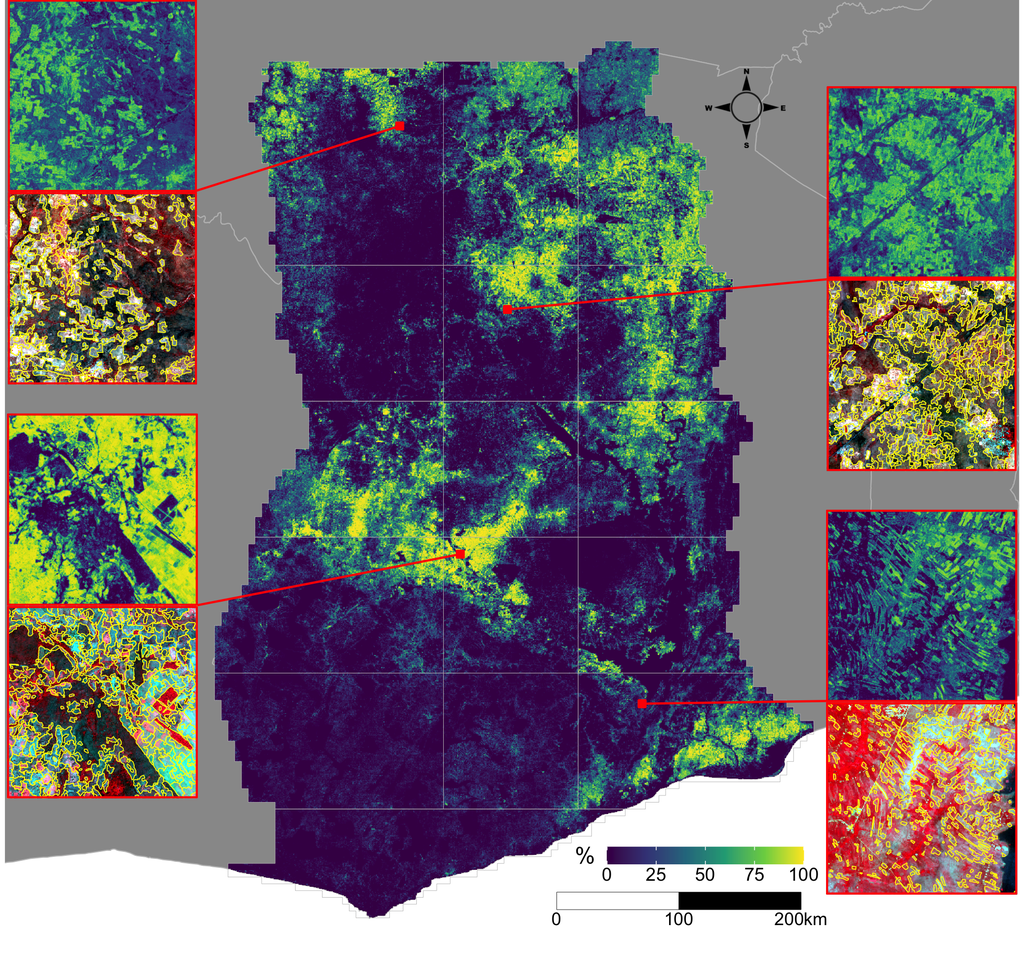

[Code for figure](https://github.com/agroimpacts/activemapper/blob/e1c238a741fd8b590e21ef1e77b89fe90a25ae4f/inst/manuscript/figures.Rmd#L454-L619)

- Examine the code and identify which parts of the code make each component of the figure.

## Today

- Assignment 3 quiz
- Intro to spatial data (`sf`)

## Spatial data

### Reading

- Create spatial points from csv

```r
library(tidyverse)
library(sf)
## read in csv
farmers <- system.file("extdata/farmer_spatial.csv", package = "geospaar") %>%
  read_csv()

## convert tibble to 'sf'
farmers_sf <- st_as_sf(farmers, coords = c("x", "y"), crs = 4326)
```

### Reading

- Reading geojsons
- Both `st_read` and `read_sf` work

```r
districts <- read_sf(system.file("extdata/districts.geojson",
                                 package = "geospaar"))
roads <- st_read(system.file("extdata/roads.geojson", package = "geospaar"))
```

### Writing

- `st_write` works as expected
- Use ‘.geojson’ (only one file)

```r
#st_write(districts, "districts_out.shp")
st_write(districts, "districts2.geojson")
```

## Projections (crs)

- Geographic coordinates are: `4326`

```r
st_crs(farmers_sf) <- 4326
farmers_sf %>% st_crs()
```

```
Coordinate Reference System:
  User input: EPSG:4326
  wkt:
GEOGCRS["WGS 84",
    ENSEMBLE["World Geodetic System 1984 ensemble",
        MEMBER["World Geodetic System 1984 (Transit)"],
        MEMBER["World Geodetic System 1984 (G730)"],
        MEMBER["World Geodetic System 1984 (G873)"],
        MEMBER["World Geodetic System 1984 (G1150)"],
        MEMBER["World Geodetic System 1984 (G1674)"],
        MEMBER["World Geodetic System 1984 (G1762)"],
        MEMBER["World Geodetic System 1984 (G2139)"],
        MEMBER["World Geodetic System 1984 (G2296)"],
        ELLIPSOID["WGS 84",6378137,298.257223563,
            LENGTHUNIT["metre",1]],
        ENSEMBLEACCURACY[2.0]],
    PRIMEM["Greenwich",0,
        ANGLEUNIT["degree",0.0174532925199433]],
    CS[ellipsoidal,2],
        AXIS["geodetic latitude (Lat)",north,
            ORDER[1],
            ANGLEUNIT["degree",0.0174532925199433]],
        AXIS["geodetic longitude (Lon)",east,
            ORDER[2],
            ANGLEUNIT["degree",0.0174532925199433]],
    USAGE[
        SCOPE["Horizontal component of 3D system."],
        AREA["World."],
        BBOX[-90,-180,90,180]],
    ID["EPSG",4326]]
```

```r
# or
farmers_sf %>% st_set_crs(NA)
```

```
Simple feature collection with 20984 features and 5 fields
Geometry type: POINT
Dimension:     XY
Bounding box:  xmin: 24.777 ymin: -18.222 xmax: 33.332 ymax: -8.997
CRS:           NA
# A tibble: 20,984 × 6
   uuid     date       season rained planted         geometry
 * <chr>    <date>      <dbl>  <dbl>   <dbl>          <POINT>
 1 009a8424 2015-11-15      1      0       0 (27.256 -16.926)
 2 00df166f 2015-11-15      1      0       0 (26.942 -16.504)
 3 02671a00 2015-11-15      1      0       0 (27.254 -16.914)
 4 03f4dcca 2015-11-15      1      0       0 (27.237 -16.733)
 5 042cf7b3 2015-11-15      1      0       0 (27.138 -16.807)
 6 05618404 2015-11-15      1      0       0 (26.875 -16.611)
 7 064beba0 2015-11-15      1      1       0 (26.752 -16.862)
 8 083a46a2 2015-11-15      1      0       0 (26.977 -16.765)
 9 08eb2224 2015-11-15      1      0       0 (26.912 -16.248)
10 0ab761d6 2015-11-15      1      0       0  (27.113 -16.95)
# ℹ 20,974 more rows
```

```r
farmers_sf %>% st_set_crs(4326)
```

```
Simple feature collection with 20984 features and 5 fields
Geometry type: POINT
Dimension:     XY
Bounding box:  xmin: 24.777 ymin: -18.222 xmax: 33.332 ymax: -8.997
Geodetic CRS:  WGS 84
# A tibble: 20,984 × 6
   uuid     date       season rained planted         geometry
 * <chr>    <date>      <dbl>  <dbl>   <dbl>      <POINT [°]>
 1 009a8424 2015-11-15      1      0       0 (27.256 -16.926)
 2 00df166f 2015-11-15      1      0       0 (26.942 -16.504)
 3 02671a00 2015-11-15      1      0       0 (27.254 -16.914)
 4 03f4dcca 2015-11-15      1      0       0 (27.237 -16.733)
 5 042cf7b3 2015-11-15      1      0       0 (27.138 -16.807)
 6 05618404 2015-11-15      1      0       0 (26.875 -16.611)
 7 064beba0 2015-11-15      1      1       0 (26.752 -16.862)
 8 083a46a2 2015-11-15      1      0       0 (26.977 -16.765)
 9 08eb2224 2015-11-15      1      0       0 (26.912 -16.248)
10 0ab761d6 2015-11-15      1      0       0  (27.113 -16.95)
# ℹ 20,974 more rows
```

## Projections (use existing)

- You can set projections based on another layer
- But the two layers MUST have the same crs (e.g. geographic)

```r
farmers <- read_csv(system.file("extdata/farmer_spatial.csv",
                                package = "geospaar"))
farmers <- st_as_sf(farmers, coords = c("x", "y")) %>%
  st_set_crs(st_crs(districts))

farmers %>% st_crs() ## print new crs
```

```
Coordinate Reference System:
  User input: WGS 84
  wkt:
GEOGCRS["WGS 84",
    DATUM["World Geodetic System 1984",
        ELLIPSOID["WGS 84",6378137,298.257223563,
            LENGTHUNIT["metre",1]]],
    PRIMEM["Greenwich",0,
        ANGLEUNIT["degree",0.0174532925199433]],
    CS[ellipsoidal,2],
        AXIS["geodetic latitude (Lat)",north,
            ORDER[1],
            ANGLEUNIT["degree",0.0174532925199433]],
        AXIS["geodetic longitude (Lon)",east,
            ORDER[2],
            ANGLEUNIT["degree",0.0174532925199433]],
    ID["EPSG",4326]]
```

## Projections (transform)

- Use `st_transform()` to project from one crs to another

```r
roads <- st_transform(x = roads, crs = st_crs(districts))
st_crs(roads)
```

```
Coordinate Reference System:
  User input: WGS 84
  wkt:
GEOGCRS["WGS 84",
    DATUM["World Geodetic System 1984",
        ELLIPSOID["WGS 84",6378137,298.257223563,
            LENGTHUNIT["metre",1]]],
    PRIMEM["Greenwich",0,
        ANGLEUNIT["degree",0.0174532925199433]],
    CS[ellipsoidal,2],
        AXIS["geodetic latitude (Lat)",north,
            ORDER[1],
            ANGLEUNIT["degree",0.0174532925199433]],
        AXIS["geodetic longitude (Lon)",east,
            ORDER[2],
            ANGLEUNIT["degree",0.0174532925199433]],
    ID["EPSG",4326]]
```

## Features from scratch

```r
pt <- st_point(x = c(28, -14))
pt
```

```
#> POINT (28 -14)
```

```r
#
# #2
pts <- st_multipoint(x = cbind(x = c(27.5, 28, 28.5), y = c(-14.5, -15, -15.5)))
pts
```

```
#> MULTIPOINT ((27.5 -14.5), (28 -15), (28.5 -15.5))
```

```r
#
# #3
sline <- st_linestring(cbind(x = c(27, 27.5, 28), y = c(-15, -15.5, -16)))
sline
```

```
#> LINESTRING (27 -15, 27.5 -15.5, 28 -16)
```

```r
#
# #4
pol <- st_polygon(list(cbind(x = c(26.5, 27.5, 27, 26, 26.5),
                             y = c(-15.5, -16.5, -17, -16, -15.5))))
pol
```

[output not shown]

### Plotting

- `sf`’s generic `plot()` (use `add = TRUE`)

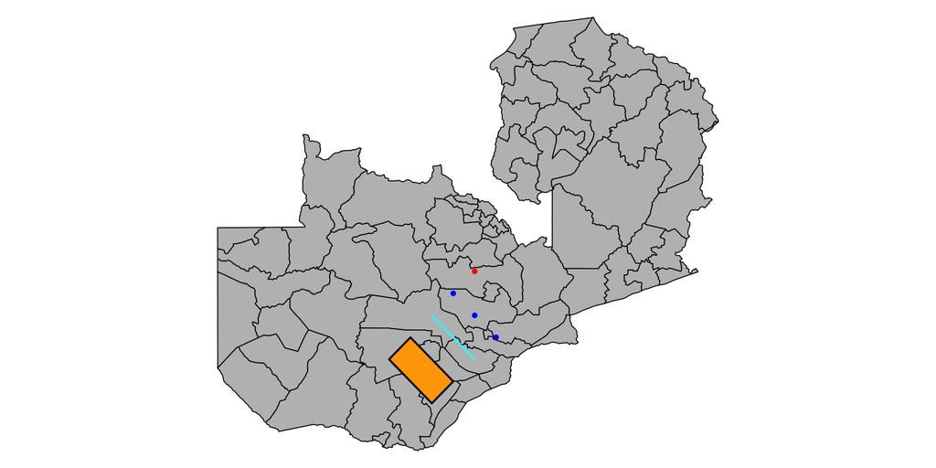

```r
par(mar = c(0, 0, 0, 0))
plot(districts %>% st_geometry(), col = "grey")
plot(pt, add = TRUE, col = "red", pch = 20)
plot(pts, add = TRUE, col = "blue", pch = 20)
plot(sline, add = TRUE, col = "cyan", lwd = 2)
plot(pol, add = TRUE, col = "orange", lwd = 2)
```

## Plotting (ggplot)

- Use `geom_sf()`

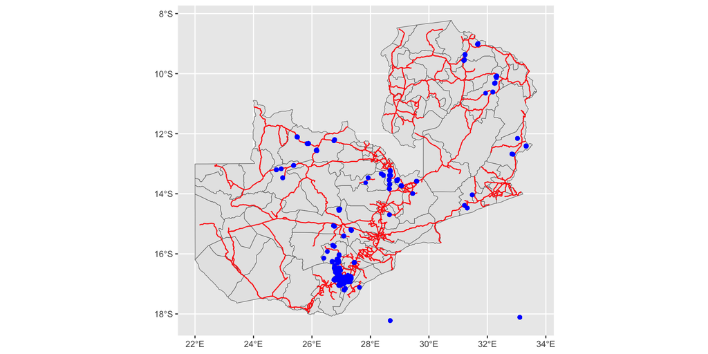

```r
ggplot(districts) + geom_sf() +
  geom_sf(data = roads, col = "red") +
  geom_sf(data = farmers_sf, col = "blue")
```

### Data

```r
districts <- st_read(system.file("extdata/districts.geojson",
                                 package = "geospaar"))
farmers_sf <- read_csv(system.file("extdata/farmer_spatial.csv",
                                   package = "geospaar"))
farmers_s <- st_as_sf(farmers, coords = c("x", "y")) %>%
  st_set_crs(st_crs(districts))

roads <- st_read(system.file("extdata/roads.geojson", package = "geospaar")) %>%
  st_transform(x = roads, crs = st_crs(districts))

pt <- st_point(x = c(28, -14))
pts <- st_multipoint(x = cbind(x = c(27.5, 28, 28.5), y = c(-14.5, -15, -15.5)))
sline <- st_linestring(cbind(x = c(27, 27.5, 28), y = c(-15, -15.5, -16)))
pol <- st_polygon(list(cbind(x = c(26.5, 27.5, 27, 26, 26.5),
                             y = c(-15.5, -16.5, -17, -16, -15.5))))
```

## Plotting (ggplot)

- Use `geom_sf()`

```r
ggplot(districts) + geom_sf() +
  geom_sf(data = roads, col = "red") +
  geom_sf(data = farmers_sf, col = "blue")
```

## Area and Length

- `st_area()`, `st_length`. Default units are in meters
- How many square m in a square km?

```r
dist_areas <- districts %>% st_area()
dist_areas
dist_areas %>% units::set_units("km^2")
```

## Add area as column

```r
districts <- districts %>%
  mutate(area = st_area(.) %>% units::set_units("km^2") %>% as.numeric())
districts
```

## Plot districts (exercise)

- Use `geom_sf()` to plot area
- Fill districts based on area column.
- Use `scale_fill_continuous` , with `type = 'viridis'`

```r
ggplot(districts) + geom_sf(aes(fill = area)) +
  scale_fill_continuous(type = "viridis")
```

## Compare areas

```r
districts <- districts %>%
  st_transform("ESRI:102022") %>%
  mutate(area2 = as.numeric(st_area(.) / 10000)) %>%
  st_transform(4326)

ggplot(districts) +
  geom_histogram(aes(x = area - area2))
```

```r
districts <- districts %>%
  mutate(areadiff = (area - area2) / area * 100)

ggplot(districts) +
  geom_point(aes(x = area2, y = areadiff))

districts %>%
  mutate(areadiff = ((area - area2) / area) * 100) %>%
  ggplot() + geom_point(aes(x = area2, y = areadiff))

districts %>%
  mutate(areadiff = ((area - area2) / area) * 100) %>%
  summarize(mu = mean(areadiff))
```

```r
districts %>%
  mutate(areadiff = ((area - area2) / area) * 100) %>%
  ggplot() + geom_sf(aes(fill = areadiff))

districts %>%
  mutate(areadiff = ((area - area2) / area) * 100) %>%
  summarize(mu = mean(areadiff)) %>%
  ggplot() + geom_sf(aes(fill = mu))

districts %>%
  mutate(areadiff = ((area - area2) / area) * 100) %>%
  st_drop_geometry() %>%
  summarize(mu = mean(areadiff)) #%>%
  # ggplot() + geom_sf(aes(fill = mu))

districts %>%
  mutate(areadiff = ((area - area2) / area) * 100) %>%
  as_tibble() %>%
  summarize(mu = mean(areadiff)) #%>%
```

## Calculate length (exercise)

```r
roads <- st_read(
  system.file("extdata/roads.geojson", package = "geospaar")
)
roads <- roads %>%
  mutate(road_length = as.numeric(units::set_units(st_length(.), "km")))
ggplot() +
  geom_sf(data = districts, color = "black", fill = NA) +
  geom_sf(data = roads, aes(color = road_length), lwd = 1) +
  scale_color_viridis_c() +
  theme_minimal()
```

## ggplot steps

- Start with `ggplot()`. You can include data if you’re only using one data set.
- Add plot type (`geom_point`, `geom_line`, `geom_sf`, `geom_histogram`)
- Add aesthetics in `aes()`. These are columns used for plotting.
- For `geom_point`, `geom_line` you need ‘x’ and ‘y’ aesthetics.
- For `geom_sf`, spatial context used for ‘x’ and ‘y’. But you might want ‘fill’ or ‘color’